# Graduate Admissions

ZackBarry

2/22/2020

```r
knitr::opts_chunk$set(echo = TRUE)
library(tidyverse)
library(DataExplorer)
library(ggridges)
library(reshape2)
library(ggfortify) # for plotting PCA
library(patchwork)
library(caret)
library(recipes)
library(knitr)
library(kableExtra)
library(ggthemes)

dataset <- read_csv("Data/Admission_Predict_Ver1.1.csv")
```

# 1 Introduction

In this document we consider a set of variables that are potentially related to a student’s chances of getting into graduate school. The population of students is limited to India. Model interpretability is a top priority as the result should be able to guide students towards the most effective application preparation.

## 1.1 Data source

# 2 Pre-Modeling Stages

## 2.1 Acquiring/Loading Data

The variable “SOP” stands for “Statement of Purpose Strength”; “LOR” stands for “Letter of Recommendation Strength”; “CGPA” is the student’s undergraduate GPA; “Research” is a boolean - 1 for did research, 0 for did not. “Chance of Admit” is the response variable, ranging from 0 to 1.

```r
dataset %>%
  glimpse()
```

```
## Observations: 500
## Variables: 9
## $ `Serial No.`        <dbl> 1, 2, 3, 4, 5, 6, 7, 8, 9, 10, 11, 12, 13, 1…
## $ `GRE Score`         <dbl> 337, 324, 316, 322, 314, 330, 321, 308, 302,…
## $ `TOEFL Score`       <dbl> 118, 107, 104, 110, 103, 115, 109, 101, 102,…
## $ `University Rating` <dbl> 4, 4, 3, 3, 2, 5, 3, 2, 1, 3, 3, 4, 4, 3, 3,…
## $ SOP                 <dbl> 4.5, 4.0, 3.0, 3.5, 2.0, 4.5, 3.0, 3.0, 2.0,…
## $ LOR                 <dbl> 4.5, 4.5, 3.5, 2.5, 3.0, 3.0, 4.0, 4.0, 1.5,…
## $ CGPA                <dbl> 9.65, 8.87, 8.00, 8.67, 8.21, 9.34, 8.20, 7.…
## $ Research            <dbl> 1, 1, 1, 1, 0, 1, 1, 0, 0, 0, 1, 1, 1, 1, 1,…
## $ `Chance of Admit`   <dbl> 0.92, 0.76, 0.72, 0.80, 0.65, 0.90, 0.75, 0.…
```

The field `Serial No.` appears to be an ID, so we’ll drop it. The columns are renamed to be easier to work with.

```r
names(dataset) <- str_replace_all(tolower(names(dataset)), " ", "_")
dataset <- select(dataset, -serial_no.)
```

## 2.2 Check for missing/out-of-range values

None of the columns contains any missing data:

```r
map_df(dataset, is.na) %>%
  map_df(sum)
```

```
## # A tibble: 1 x 8
##   gre_score toefl_score university_rati…   sop   lor  cgpa research
##       <int>       <int>            <int> <int> <int> <int>    <int>
## 1         0           0                0     0     0     0        0
## # … with 1 more variable: chance_of_admit <int>
```

The allowed range for each variable is as follows:

- GRE Scores ( out of 340 )
- TOEFL Scores ( out of 120 )
- University Rating ( out of 5 )
- Statement of Purpose and Letter of Recommendation Strength ( out of 5 )
- Undergraduate GPA ( out of 10 )
- Research Experience ( either 0 or 1 )
- Chance of Admit ( ranging from 0 to 1 )

Each variable is within the expected range, so there is no apparent need to clean the data.

```r
rbind(
  map_df(dataset, min),
  map_df(dataset, max)
)
```

```
## # A tibble: 2 x 8
##   gre_score toefl_score university_rati…   sop   lor  cgpa research
##       <dbl>       <dbl>            <dbl> <dbl> <dbl> <dbl>    <dbl>
## 1       290          92                1     1     1  6.8         0
## 2       340         120                5     5     5  9.92        1
## # … with 1 more variable: chance_of_admit <dbl>
```

## 2.3 Distribution of explanatory variables

In this section we check which explanatory variables have enough variance to be useful in explaining the variance in the response variable.

First we’ll check on the relationship between each of the continuous explanatory variables and admission chances. Since each of these variables is a score where higher is better, we’d expect that as the students’ scores go up so do their admission chances. We’ll leave the non-student variable `university_rating` for later.

We see that as GRE Score, CPGA, and TOEFL Score increase, the chance of admission also tends to increase. The relationship between CPGA and admission chance is especially clear. It will be interested to see how correlated this scores are.

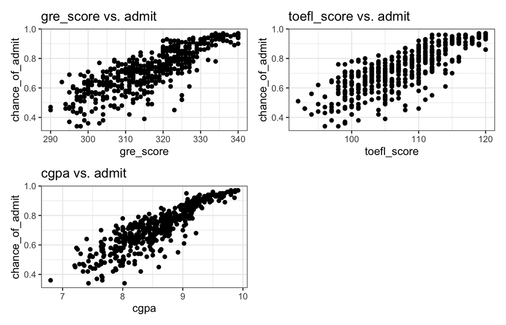

```r
continuous_plots <- lapply(
  c("gre_score", "toefl_score", "cgpa"),
  function(x) {
    wrapr::let(
      alias = list(X_VAR = x, Y_VAR = "chance_of_admit"),
      expr = {
        ggplot(dataset, aes(x = X_VAR, y = Y_VAR)) +
          geom_point() +
          theme_bw() +
          labs(title = paste(x, "vs. admit"), x = x, y = "chance_of_admit")
      }
    )
  }
)

wrap_plots(continuous_plots, ncol = 2)
```

Next, consider the distribution of `chance_of_admit` for each level of the letter of recommendation (`lor`) and statement of purpose (`sop`) scores. The plots are very similar – admission chances tend to rise alongisde `lor` and `sop`. The distributions at each level of `sop` seem to have lower variance than for `lor`, indicating that there might be a stronger relationsihip between `sop` and `chance_of_admit` than between `lor` and `chance_of_admit`. This is interesting because the statement of purporse is entirely student-driven where as letter of recommendations are instructor-driven.

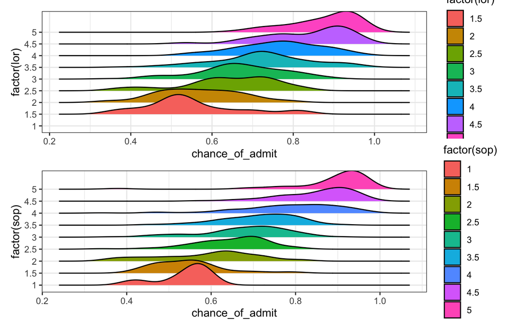

```r
p1 <- ggplot(dataset, aes(x = chance_of_admit, y = factor(lor))) +
  geom_density_ridges(aes(fill = factor(lor))) +
  theme_bw()

p2 <- ggplot(dataset, aes(x = chance_of_admit, y = factor(sop))) +
  geom_density_ridges(aes(fill = factor(sop))) +
  theme_bw()

p1 / p2
```

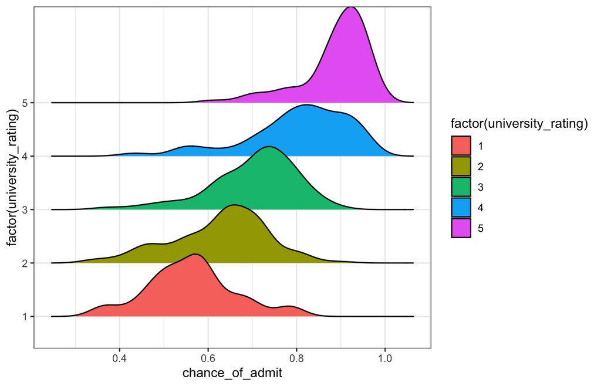

```r
ggplot(dataset, aes(x = chance_of_admit, y = factor(university_rating))) +
  geom_density_ridges(aes(fill = factor(university_rating))) +
  theme_bw()
```

Now looking at the number of observations of research vs. no research for different levels of `chance_of_admit`, we see that students who participated in research have higher chance of admission. In fact, there are no observations of students with higher than a 90% chance of admission without doing research, and there are very few observations of students with higher than 80% chance. However, we should recall from the university rating ridge plot above that most observations where chance of admit is higher than 80% have university rankings of 4 or 5.

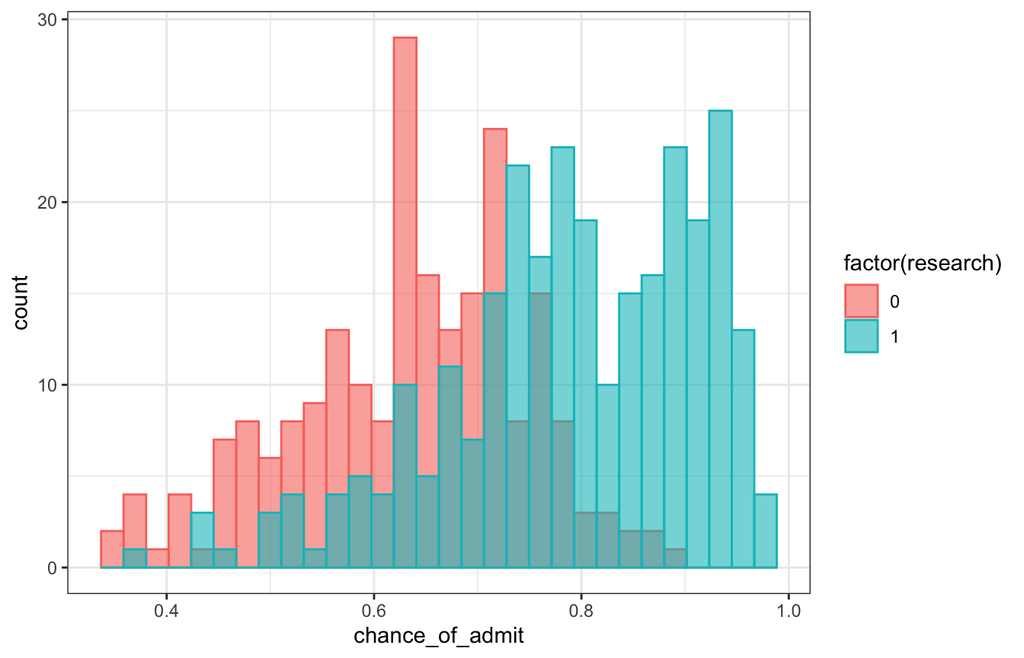

```r
ggplot(dataset, aes(x = chance_of_admit, fill = factor(research), color = factor(research))) +
  geom_histogram(position="identity", alpha=0.6) +
  theme_bw()
```

We see that each variable is moderately correlated with each other variable. In particular, we see that `cpga`, `gre_score`, and `toefl_score` are all highly correlated with one another and that `cpga` is the most highly correlated with `chance_of_admit`. High correlation among explanatory variables can decrease model accuracy due to multicollinearity. In the next section we’ll explore a dimensionality reduction technique called Primary Component Analysis that builds a new set of uncorrelated explanatory variables.

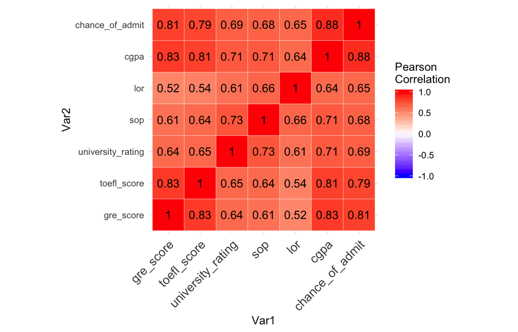

```r
get_cor_matrix_plot <- function(df, round_to = 2) {
  cor_matrix <- round(cor(df), round_to)
  melted_cor_matrix <- melt(cor_matrix)

  ggplot(melted_cor_matrix, aes(x = Var1, y = Var2, fill = value)) +
    geom_tile(color = "white") +
    scale_fill_gradient2(
      low = "blue", high = "red", mid = "white",
      midpoint = 0, limit = c(-1,1), space = "Lab",
      name="Pearson\nCorrelation"
    ) +
    theme_minimal() +
    theme(
      axis.text.x = element_text(angle = 45, vjust = 1,
      size = 12, hjust = 1)
    ) +
    coord_fixed() +
    geom_text(aes(Var1, Var2, label = value), color = "black", size = 4)
}

get_cor_matrix_plot(select(dataset, -research))
```

Each of the continuous features approximately normal, as evidenced by the plots below. Since one of the assumptions of linear regression is that the explanatory variables should be normally distributed, this encourages us to consider a multiple (or single) linear regression model.

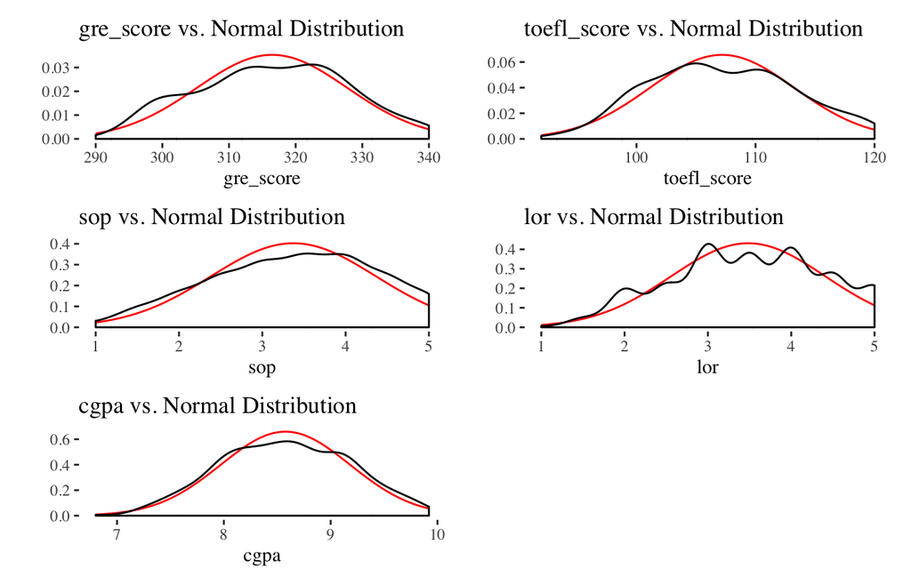

```r
get_hist_and_normal_plot <- function(dataset, var_name, na.rm = T) {
  wrapr::let(
    alias = list(VAR = var_name),
    expr = {
      mean <- mean(dataset$VAR, na.rm = na.rm)
      sd   <- sd(dataset$VAR, na.rm = na.rm)

      ggplot(dataset, aes(x = VAR)) +
        stat_function(fun = dnorm,
                      n = 100,
                      args = list(mean = mean, sd = sd), color = "red")  +
        labs(title = sprintf("%s vs. Normal Distribution", var_name), y = "") +
        geom_density() +
        theme_tufte()
    }
  )
}

plots <- lapply(c("gre_score", "toefl_score", "sop", "lor", "cgpa"), get_hist_and_normal_plot, dataset = dataset)
wrap_plots(plots, ncol = 2, nrow = 3)
```

## 2.4 Dimensionality Reduction

Primary Component Analysis (PCA) is a linear algebra technique for combining several correlated variables into a chosen number of uncorrelated variables. The uncorrelated variables are constructed through linear combinations of the original variables; the uncorrelated variables are successively created to explain as much variance as possible. Since our dataset has so many highly correlated variables, this feature engineering process could lead to better test accuracy. However, an important goal of the end model is interpretability since students will want to know what factors are most important for getting into grad school. We’ll need to keep this in mind when comparing the final PCA-based model with the non-PCA model.

We’ll use the `stats` function `prcomp` to apply PCA to our dataset. Before PCA we need to normalize our variables to “level the playing field” before the algorithm creates linear combinations of the input variables.

```r
to_pca <- dataset[, !(names(dataset) %in% c("research", "chance_of_admit"))]
to_pca <- map_df(to_pca, function(x) { (x - mean(x)) / sd(x) })

pca_set <- prcomp(to_pca)
pca_values <- cbind(pca_set$x, dataset[, names(dataset) %in% c("research", "chance_of_admit")])
```

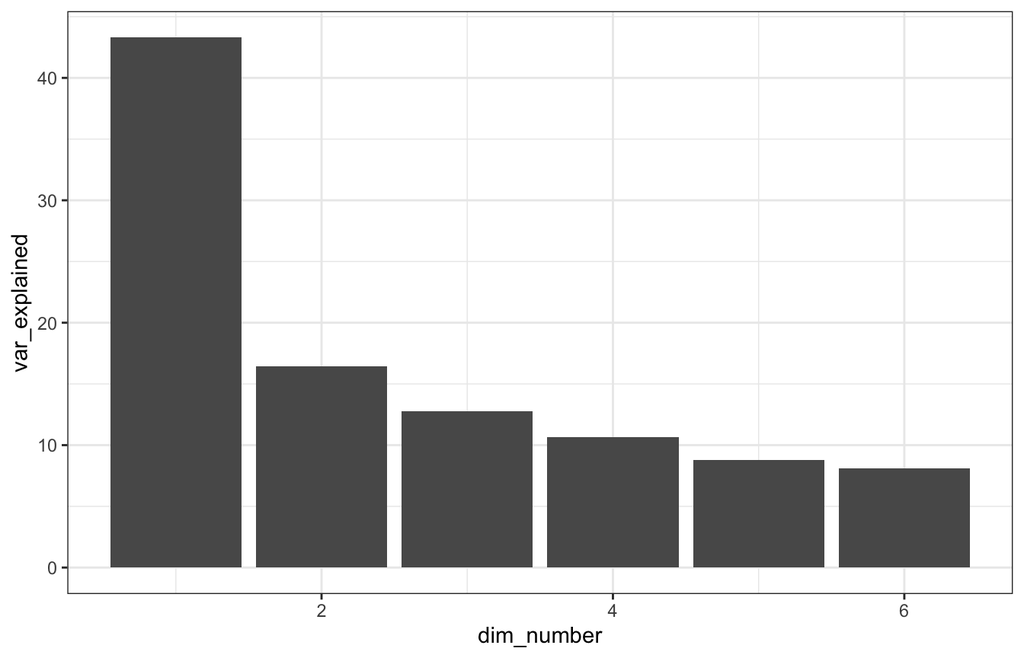

```r
var_exp <- data.frame(
  var_explained = 100 * pca_set$sdev / sum(pca_set$sdev),
  dim_number = 1:length(pca_set$sdev)
)

ggplot(var_exp, aes(x = dim_number, y = var_explained)) +
  geom_col() +
  theme_bw()
```

To get a sense for how the new variables created by PCA are related to `chance_of_admit`, consider the scatter plots below. `PC1` and `chance_of_admit` are very clearly negatively correlated. None of the other components appear to have much of a direct relationship with `chance_of_admit`. This observation is supported by the correlation matrix below. Our naive model choice is then to simply regress `chance_of_admit` onto `PC1`. It will be interesting to see if multiple linear regression or a tree based method will offer much improvement.

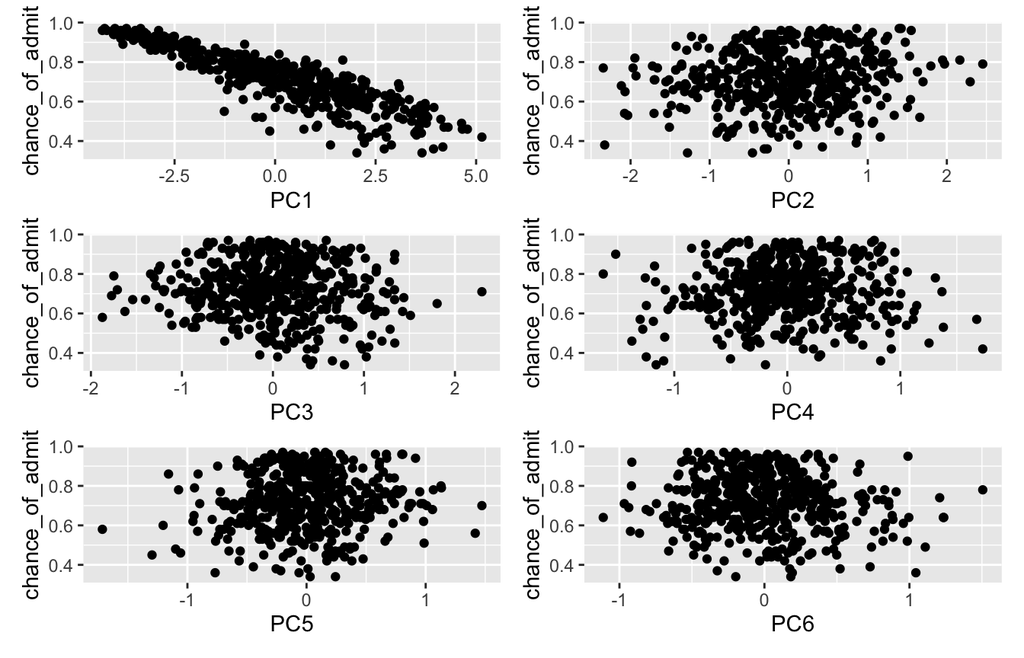

```r
get_scatter_plots <- function(x_name, y_name, dataset) {
  wrapr::let(
    alias = list(X_VAR = x_name, Y_VAR = y_name),
    expr = {
      ggplot(dataset, aes(x = X_VAR, y = Y_VAR)) +
        geom_point()
    }
  )
}

scatter_plots <- lapply(paste0("PC", 1:6),
                        get_scatter_plots,
                        y_name = "chance_of_admit",
                        dataset = pca_values)

wrap_plots(scatter_plots, ncol = 2, nrow = 3)
```

`PC1` is highly correlated with `chance_of_admit` while none of the other components are.

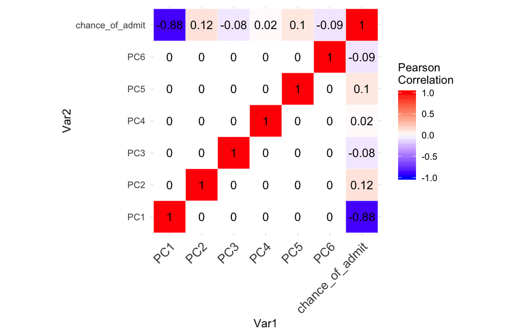

```r
get_cor_matrix_plot(select(pca_values, -research))
```

Just as the original continuous features were approximately normal, so are each of the features extracted by our PCA analysis. Since one of the assumptions of linear regression is that the explanatory variables should be normally distributed, this encourages us to consider a multiple (or single) linear regression model.

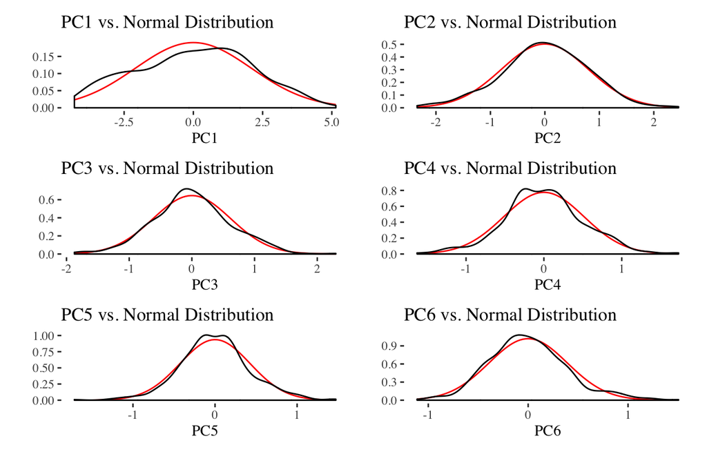

```r
plots <- lapply(paste0("PC", 1:6), get_hist_and_normal_plot, dataset = pca_values)
wrap_plots(plots, ncol = 2, nrow = 3)
```

# 3 Model Building/Evaluation

Split dataset 80/20 into train and test. Note that some combinations of `university_rating` and `research` have relatively few observations. We group by those variables when splitting the dataset to ensure some observations show up in each.

```r
set.seed(541)

dataset_with_index <- dataset %>%
  group_by(university_rating, research) %>%
  mutate(set = sample(c("train", "test"), size = n(), replace = TRUE, prob = c(0.8, 0.2)))

train <- filter(dataset_with_index, set == "train") %>%
  select(-set)
test  <- filter(dataset_with_index, set == "test") %>%
  select(-set)
```

## 3.1 Model Fitting Part 1: No PCA

### 3.1.1 Data Prep Recipe

Create recipe for feature preparation - center and scale (normalize) the variables:

```r
feature_recipe <- recipe(chance_of_admit ~ ., data = train) %>%
  step_center(-research, -all_outcomes()) %>%
  step_scale(-research, -all_outcomes())
```

### 3.1.2 Variable Selection

For variable selection we’ll be using backwards feature selection, also known as recursive feature elimination (RFE). RFE selects features by recursively considering smaller sets of features until only 1 feature remains. That is, RFE fits a model using $N$ explanatory variables, removes the least significant variable, and then repeats the process with the $N-1$ reamaining variables. The set of variables used to create the model with the lowest estimated test error is the set used for the final model. In our case, we’ll be estimating the test error using cross-validation.

Based on the discussion above about the normality of the primary components, multiple linear regression is the model we’ll be fitting. RMSE will be used as metric by which to identify the best performing subset of variables.

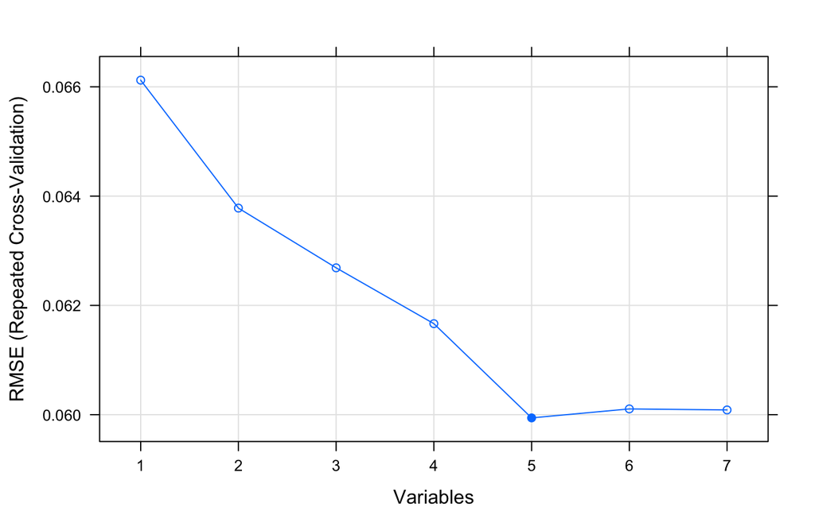

```r
set.seed(503)

ctrl <- rfeControl(functions = lmFuncs,
                   method = "repeatedcv",
                   repeats = 5,
                   verbose = FALSE)

lmProfile <- rfe(feature_recipe,
                 data = train,
                 metric = "RMSE",
                 rfeControl = ctrl,
                 sizes = 1:7)

plot(lmProfile, type = c("g", "o"))
```

```r
lmProfile$results %>%
  filter(Variables %in% c(5, 6)) %>%
  select(Variables, RMSE, Rsquared) %>%
  kable(format = "html") %>%
  kable_styling()
```

| Variables | RMSE | Rsquared |
| --- | --- | --- |
| 5 | 0.0599415 | 0.8256671 |
| 6 | 0.0601058 | 0.8247154 |

To avoid overfitting, we’ll choose the model with 5 variables as the most important. Those top 5 variables are:

```r
lmProfile$variables %>%
  filter(Variables == 5) %>%
  distinct(var) %>%
  kable(format = "html") %>%
  kable_styling()
```

| var |
| --- |
| cgpa |
| research |
| toefl_score |
| lor |
| gre_score |

## 3.2 Model Fitting Part 2: PCA

For model fitting, we need to be careful about when we apply PCA. In the EDA section above, we extracted primary components by analyzing the entire data set. However, this leaks data about the test set into the training process. Therefore we need to define our PCA process on the training set alone and later apply it to the test set when we are ready to test the model. This includes the normalization of the explanatory variables – to normalize the test set, we will subtract the mean of the training set and divide by the standard deviation of the training set.

### 3.2.1 Data Prep Recipe

Create recipe for feature preparation - center and scale (normalize) the variables used for PCA in the EDA section before applying PCA. Note that we ask the `step_pca` function to keep all components rather than using an explained variance threshold. This allows us to do our own variable selection later on.

```r
feature_recipe_pca <- recipe(chance_of_admit ~ ., data = train) %>%
  step_center(-research, -all_outcomes()) %>%
  step_scale(-research, -all_outcomes()) %>%
  step_pca(-research, -all_outcomes(), num_comp = 6)
```

### 3.2.2 Variable Selection

For variable selection we’ll be using the same method as in Model Fitting Part 1 – recursive feature elimination with cross-validation.

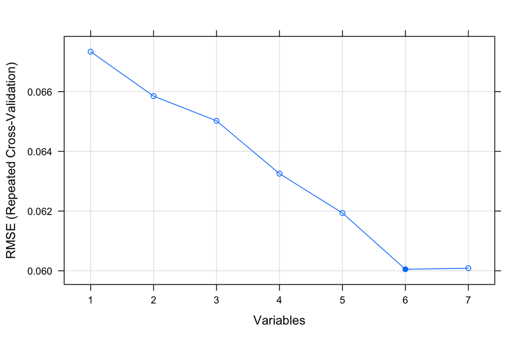

```r
set.seed(503)

ctrl <- rfeControl(functions = lmFuncs,
                   method = "repeatedcv",
                   repeats = 5,
                   verbose = FALSE)

lmProfile_pca <- rfe(feature_recipe_pca,
                     data = train,
                     metric = "RMSE",
                     rfeControl = ctrl,
                     sizes = 1:7)

plot(lmProfile_pca, type = c("g", "o"))
```

```r
lmProfile_pca$results %>%
  filter(Variables %in% c(5, 6)) %>%
  select(Variables, RMSE, Rsquared) %>%
  kable(format = "html") %>%
  kable_styling()
```

| Variables | RMSE | Rsquared |
| --- | --- | --- |
| 5 | 0.0619364 | 0.8144378 |
| 6 | 0.0600513 | 0.8251570 |

```r
predictors(lmProfile)
```

```
## [1] "cgpa"        "research"    "toefl_score" "gre_score"   "lor"
```

## 3.3 Fitting/Testing Final Model

First, apply the recipe to the train/test data:

```r
fit_feature_recipe <- prep(feature_recipe, training = train)

train_baked <- bake(fit_feature_recipe, train)
test_baked  <- bake(fit_feature_recipe, test)
```

Next, fit a linear model using the 5 variables selected by RFE:

```r
model <- lm(chance_of_admit ~ cgpa + research + gre_score + lor + toefl_score, data = train_baked)
```

Lastly, predict `chance_of_admit` on the test set and consider the results:

```r
predicted <- predict(model, test_baked)

results <- test_baked %>%
  mutate(predicted = predicted) %>%
  mutate(residual = predicted - chance_of_admit)
```

```r
sqrt(mean(results$residual ^ 2))
```

```
## [1] 0.06003708
```

```r
summary(model)$r.squared
```

```
## [1] 0.8238991
```

Additionally, each of the predictor variables was statistically significant at an 0.05 confidence level as evidenced by the coefficient p-values:

```r
summary(model)
```

```
##
## Call:
## lm(formula = chance_of_admit ~ cgpa + research + gre_score +
##     lor + toefl_score, data = train_baked)
##
## Residuals:
##       Min        1Q    Median        3Q       Max
## -0.261506 -0.024478  0.007325  0.035199  0.159850
##
## Coefficients:
##             Estimate Std. Error t value Pr(>|t|)
## (Intercept) 0.707380   0.005236 135.093  < 2e-16 ***
## cgpa        0.076177   0.006333  12.028  < 2e-16 ***
## research    0.029027   0.007633   3.803 0.000166 ***
## gre_score   0.018578   0.006496   2.860 0.004467 **
## lor         0.017369   0.003931   4.419 1.29e-05 ***
## toefl_score 0.020005   0.005771   3.466 0.000587 ***
## ---
## Signif. codes:  0 '***' 0.001 '**' 0.01 '*' 0.05 '.' 0.1 ' ' 1
##
## Residual standard error: 0.06016 on 386 degrees of freedom
## Multiple R-squared:  0.8239, Adjusted R-squared:  0.8216
## F-statistic: 361.2 on 5 and 386 DF,  p-value: < 2.2e-16
```

Linear regression models should have normally distributed residuals. The residuals should also have mean zero and by independent and randomly distributed. These assumption are satisfied reasonably well by our model:

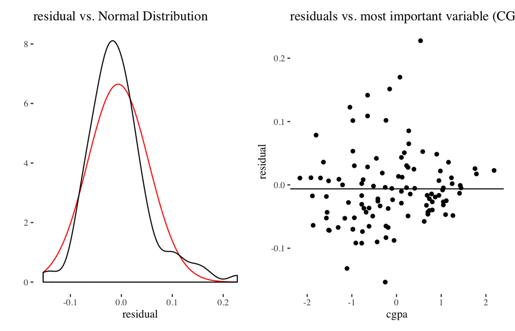

```r
p1 <- get_hist_and_normal_plot(results, "residual")
p2 <- ggplot(results, aes(x = cgpa, y = residual)) +
  geom_point() +
  geom_abline(slope = 0, intercept = mean(results$residual)) +
  theme_tufte() +
  labs(title = "residuals vs. most important variable (CGPA)")

p1 + p2
```

## 3.4 Interpreting Final Model

```r
varImp(model) %>%
  kable(format = "html") %>%
  kable_styling()
```

|  | Overall |
| --- | --- |
| cgpa | 12.028427 |
| research | 3.802771 |
| gre_score | 2.859966 |
| lor | 4.418691 |
| toefl_score | 3.466362 |

The coefficients of the model are all positive. This is very much in line with our expectations - increasing a student’s GPA, GRE Score, Letter of Rec Score, or TOEFL score all increases their chance of admission.

```r
coefficients(model)
```

```
## (Intercept)        cgpa    research   gre_score         lor toefl_score
##  0.70738036  0.07617744  0.02902694  0.01857793  0.01736857  0.02000539
```

# 4 Conclusion

We set out to predict students’ chance of admission at universities based on their academic history and application materials. Many of these explanatory variables turned out to be highly correlated with one another, so primary component analysis was used to create an alternative set of uncorrelated features. After applying Recursive Feature Elimination to a linear regression model with the original and then uncorrelated features, it became clear the the multicollinearity was not much of a problem. In order to maintain the interpretability of the final model, the original predictors were used.